# 21 DiD3 Differential Timing Difference-in-Differences

ECON 474 Econometrics of Policy Evaluation

As always, we are going to begin by loading in some packages and the data. While we are at it, we can discuss what variables are in the data.

```r
library(tidyverse)
library(fixest)
library(stringr)

castle = read_csv("C:/Users/johnj/Dropbox/Julian/Academia/UIUC/Semester 11 Fall 2022/ECON474/Data/DiD3 castle.csv")
names(castle)
```

```
##  [1] "state"            "year"             "region"           "treated"
##  [5] "cdl"              "l_motor"          "l_larceny"        "l_robbery"
##  [9] "l_assault"        "l_homicide"       "blackm_15_24"     "whitem_15_24"
## [13] "blackm_25_44"     "whitem_25_44"     "l_exp_subsidy"    "l_exp_pubwelfare"
## [17] "l_police"         "unemployrt"       "poverty"          "l_income"
## [21] "l_prisoner"       "l_lagprisoner"    "popwt"
```

# 1 Event Study: Figure 2a-ish

The variable that indicates post-treatment status is `cdl`, which stands for Castle Doctrine Law. The authors defined this variable to be the proportion of the year in which the law applies. In other words, it is not a binary variable:

```r
table(castle$cdl)
```

```
##
##                 0 0.161643832921982 0.246575340628624 0.295890420675278
##               455                 1                 2                 1
## 0.306849300861359 0.328767120838165 0.339726030826569 0.375342458486557
##                 1                 1                 1                 1
## 0.413698643445969 0.468493163585663               0.5 0.558904111385345
##                 1                 1                 4                 1
## 0.580821931362152 0.600000023841858  0.60821920633316 0.676712334156036
##                 1                 1                 1                 1
## 0.684931516647339 0.838356137275696                 1
##                 1                 1                74
```

However, this is not an issue for event study figures because we force the baseline time period just before treatment to be zero (or in this case, when treatment is not active for the entire year). We are going create the variable `event_time` for our regression as a factor in a few steps, the last of which will use the function `forcats::fct_relevel()` to create the baseline event time period.

*Note that* `event_time` *is the equivalent to* `post`. *That is, it only exists for treated states and not for untreated states*.

```r
df = castle %>%
  filter(treated == 1 &
           cdl < 1) %>%
  group_by(state) %>%
  summarise(reform_year = tail(year, 1)) %>%
  full_join(castle) %>%
  mutate(event_time = year - reform_year + 0,
         event_time = ifelse(is.na(event_time), 0, event_time),
         event_time = factor(event_time),
         event_time = fct_relevel(event_time, "0"))
```

Time to run the differential timing difference-in-differences event study regression! Remember, we are using the two-way fixed effects version of the standard difference-in-differences regression.

Throughout the paper, the authors estimate regressions weighted by the average state population from 2000-2010 and cluster the standard errors by state. The clustering will be automatic from specifying the fixed effects, however, we need to manually specify the weighted regression.

```r
fit_event = feols(l_homicide ~ event_time | state + year,
      data = df,
      weights = df$popwt) %>% summary
```

The next step is to create a data frame to create the figure. Our regression only estimates the event time coefficients, so we do not need to trim them. Additionally, we can grab the event time directly from the variable names using the function `stringr::str_sub()`.

```r
# coef(fit_event)
# str_sub(names(coef(fit_event)), 11, -1)
# as.numeric(str_sub(names(coef(fit_event)), 11, -1))

df_event =
  cbind(coef(fit_event),
      confint(fit_event, cluster = 'state')) %>%
  mutate(event_time = as.numeric(str_sub(names(coef(fit_event)), 11, -1))) %>%
  rbind(c(0, 0, 0, 0))
```

Now for the figure!

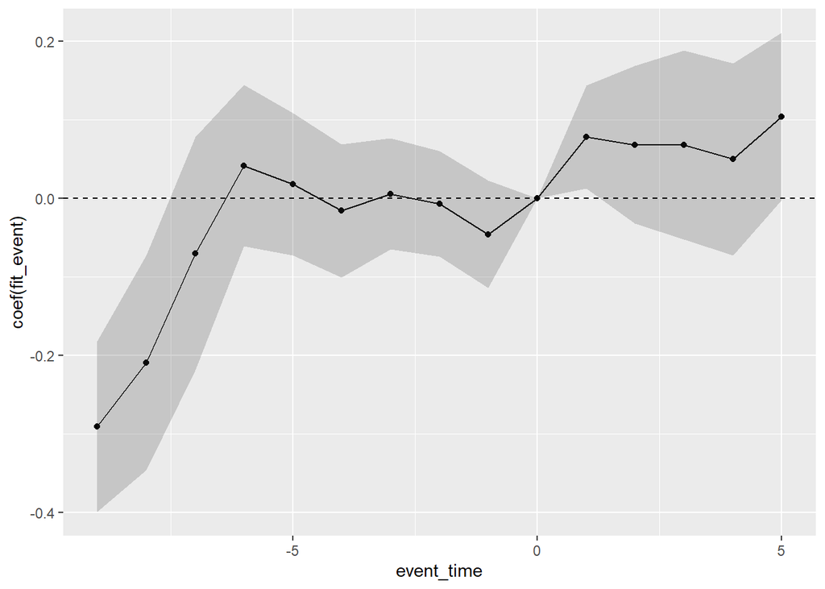

```r
ggplot(df_event, aes(x = event_time, y = `coef(fit_event)`,
                     ymin = `2.5 %`, ymax = `97.5 %`)) +
  geom_point() +
  geom_line() +
  geom_ribbon(alpha = 0.2) +
  geom_hline(yintercept = 0,
             linetype = 'dashed')
```

The left hand side of the figure significantly dips below zero. What’s going on there?

## 1.1 Unbalanced Event Time Panel

Firstly, the panel is balanced.

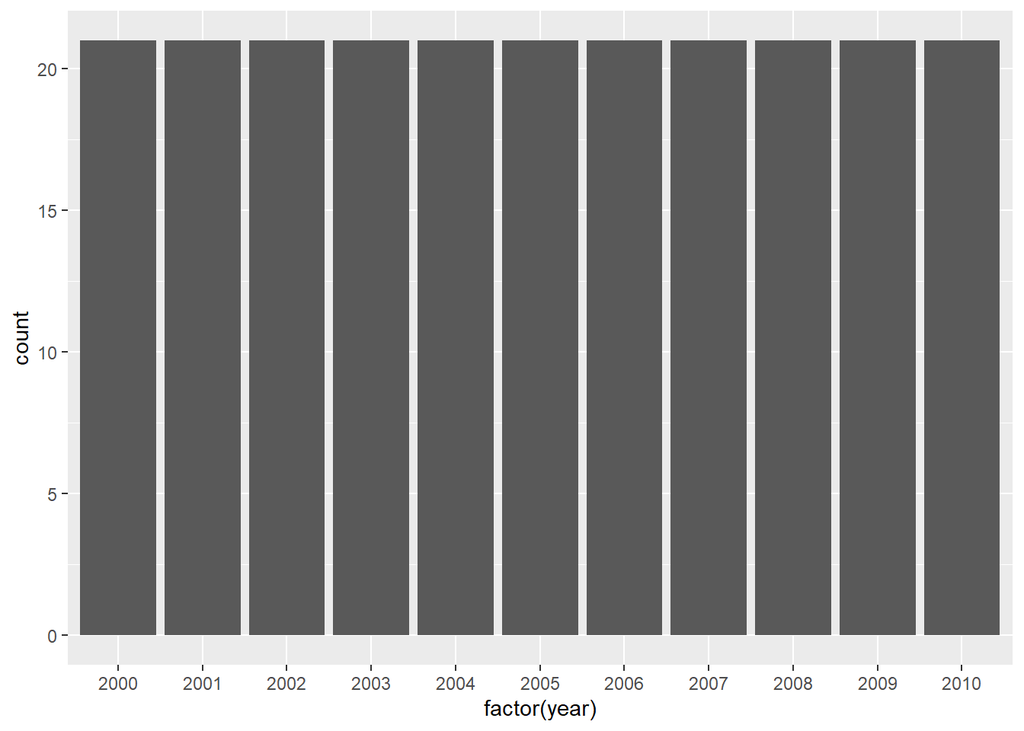

```r
castle %>%
  filter(treated == 1) %>%
  ggplot(aes(x = factor(year))) +
  geom_bar()
```

Specifically, the data are balanced in year-time. Because different states were treated in different years, the data are not balanced in event time:

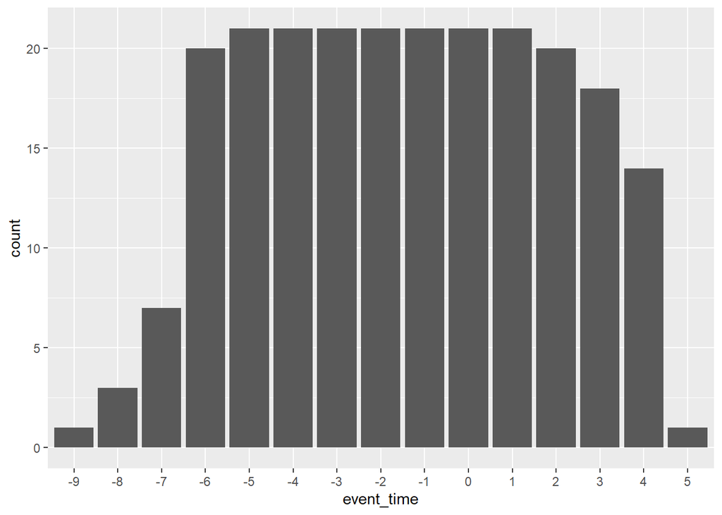

```r
df %>%
  na.omit() %>%
  mutate(event_time = fct_relevel(event_time, "0", after = 9)) %>%
  ggplot(aes(x = event_time)) +
  geom_bar()
```

Typically the thing to do in this situation is to trim the observations to only have a balanced event-time panel (or at least a mostly balanced panel), but the authors do not do this.

# 2 Lab

Now it’s your turn!

## 2.1 Main Results: Table 5 Columns 1-3

```r
fit1_2 = feols(l_homicide ~ cdl | csw(state + year, region:year),
             data = castle,
             weights = castle$popwt)
fit3 =  feols(l_homicide ~ cdl + l_police + unemployrt + poverty +
                                 l_income + l_prisoner + l_lagprisoner +
                                 l_exp_subsidy + l_exp_pubwelfare +
                                 blackm_15_24 + whitem_15_24 + blackm_25_44 + whitem_25_44 |
                state + year + region:year,
              data = castle,
              weights = castle$popwt)

etable(fit1_2, fit3,
       se.below = TRUE,
       keep = 'cdl',
       extralines = list('Time-Varying Controls' = c('No', "No", 'Yes')))
```

```
##                       fit1_2[[.. fit1_2[[..       fit3
## Dependent Var.:       l_homicide l_homicide l_homicide
##
## cdl                      0.0801*   0.0946**   0.0937**
##                         (0.0342)  (0.0282)   (0.0294)
## Time-Varying Controls         No         No        Yes
## Fixed-Effects:        ---------- ---------- ----------
## state                        Yes        Yes        Yes
## year                         Yes        Yes        Yes
## year:region                   No        Yes        Yes
## _____________________ __________ __________ __________
## S.E.: Clustered        by: state  by: state  by: state
## Observations                 550        550        550
## R2                       0.93417    0.94109    0.94538
## Within R2                0.03018    0.03020    0.10074
## ---
## Signif. codes: 0 '***' 0.001 '**' 0.01 '*' 0.05 '.' 0.1 ' ' 1
```

## 2.2 Robustness Checks - Table 4 Column 3

The authors consider alternative mechanisms that could be driving their main findings by exploring the relationship between CDL laws and crimes that should be unrelated.

All in one line:

1. Use the third specification from the previous table in `feols()` with the outcome specified using `c()` wrapped around the four outcomes: `l_larceny`, `l_motor`, `l_robbery`, `l_assault`
2. use `%>%` to chain on `etable()` (which automatically inputs the regression as the first argument) and specify the argument `keep` equal to `"cdl"`.

```r
feols(c(l_larceny, l_motor, l_robbery, l_assault) ~ cdl + l_police + unemployrt + poverty +
        l_income + l_prisoner + l_lagprisoner +
        l_exp_subsidy + l_exp_pubwelfare +
        blackm_15_24 + whitem_15_24 + blackm_25_44 + whitem_25_44 |
        state + year + region:year,
      data = castle,
      weights = castle$popwt) %>%
  etable(se.below = TRUE,
         keep = 'cdl')
```

```
##                   model 1  model 2   model 3   model 4
## Dependent Var.: l_larceny  l_motor l_robbery l_assault
##
## cdl              -0.0091  -0.0252    0.0262    0.0372
##                  (0.0141) (0.0401)  (0.0232)  (0.0324)
## Fixed-Effects:  --------- -------- --------- ---------
## state                 Yes      Yes       Yes       Yes
## year                  Yes      Yes       Yes       Yes
## year:region           Yes      Yes       Yes       Yes
## _______________ _________ ________ _________ _________
## S.E.: Clustered by: state by: st.. by: state by: state
## Observations          550      550       550       550
## R2                0.97752  0.97425   0.98200   0.97407
## Within R2         0.05422  0.05271   0.06224   0.23102
## ---
## Signif. codes: 0 '***' 0.001 '**' 0.01 '*' 0.05 '.' 0.1 ' ' 1
```

Did you find evidence that the CDL affected crimes that should be unrelated to the law?